# MAT150 - Chapter 1

The Role of Statistics and Data Analysis Process

09/08/2022

**Statistics** is the scientific discipline that provides methods to help us make sense of data.

## 1.1. Why Study Statistics?

- Extract information from tables, charts, and graphs.
- Follow numerical arguments.
- Understand the basics of how data should be gathered, summarized, and analyzed to draw statistical conclusions.

> **Goal**: understand and use data to make decisions.
- Decide whether existing data is adequate or whether additional information is required.
- If necessary, collect more information in a reasonable and thoughtful way.
- Summarize the available data in a useful and informative manner.
- Analyze the available data.
- Draw conclusions, make decisions, and assess the risk of an incorrect decision.

Statistical methods allow us to collect, describe, analyze and draw conclusions from data.

## 1.2. The Nature and Role of Variability

Understanding variability is the key to learning from data.

**Example**: In efforts to monitor water quality, a specialist selects five water specimens each day. The concentration of contaminants in parts per million (ppm) is measured and recorded. The *histogram* below summarizes the average contamination each day for 200 days.

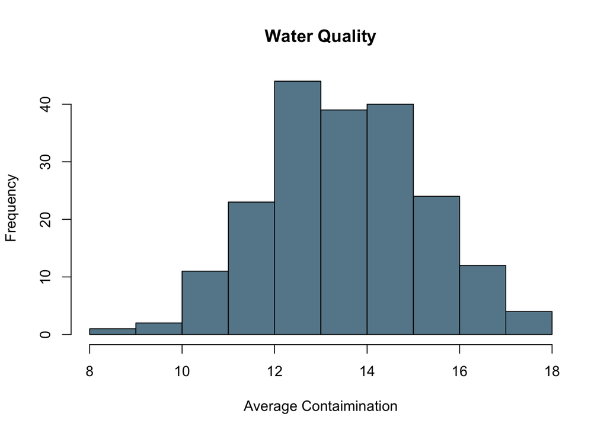

```r
# 200 Random Water Samples and concentration of chemicals in ppm.
water = rnorm(200,13.5,1.75)
hist(water, col = "#668899", xlab = "Average Contaimination", main = "Water Quality")
```

##### Consider

If there was a reported chemical spill from a industrial plant 1 mile away and the recorded average of the 5 samples was 15 ppm, would you interpret this as evidence that the water is affected by the spill? What about 17 ppm? 22 ppm?

## 1.3. Statistics and the Data Analysis Process

Statistics involves collecting, summarizing, and analyzing data.

The **data analysis process** can be organized into the following six steps:

1. **Understanding the nature of the problem**. Effective data analysis requires an understanding of the research problem. We must know the goal of the research and what questions we hope to answer. It is important to have a clear direction before gathering data to ensure that we will be able to answer the questions of interest using the data collected.
2. **Deciding what to measure and how to measure it**. The next step in the process is deciding what information is needed to answer the questions of interest. In some cases, the choice is obvious (for example, in a study of the relationship between the weight of a Division I football player and position played, you would need to collect data on player weight and position), but in other cases the choice of information is not as straightforward (for example, in a study of the relationship between preferred learning style and intelligence, how would you define learning style and measure it and what measure of intelligence would you use?). It is important to carefully define the variables to be studied and to develop appropriate methods for determining their values.
3. **Data collection**. The data collection step is crucial. The researcher must first decide whether an existing data source is adequate or whether new data must be collected. Even if a decision is made to use existing data, it is important to understand how the data were collected and for what purpose, so that any resulting limitations are also fully understood and judged to be acceptable. If new data are to be collected, a careful plan must be developed, because the type of analysis that is appropriate and the subsequent conclusions that can be drawn depend on how the data are collected.
4. **Data summarization and preliminary analysis**. After the data are collected, the next step usually involves a preliminary analysis that includes summarizing the data graphically and numerically. This initial analysis provides insight into important characteristics of the data and can provide guidance in selecting appropriate methods for further analysis.
5. **Formal data analysis**. The data analysis step requires the researcher to select and apply statistical methods. Much of this textbook is devoted to methods that can be used to carry out this step.
6. **Interpretation of results**. Several questions should be addressed in this final step. Some examples are: What can we learn from the data? What conclusions can be drawn from the analysis? and How can our results guide future research? The interpretation step often leads to the formulation of new research questions, which, in turn, leads back to the first step. In this way, good data analysis is often an iterative process.

### Definitions

> The **population** of interest is the entire collection of individuals or objects about which information is desired.

> A **sample** is a subset of the population, selected for study.

> **Descriptive statistics** is the branch of statistics that includes methods for organizing and summarizing data.

> **Inferential statistics** is the branch of statistics that involves generalizing from a sample to the population from which the sample was selected and assessing the reliability of such generalizations.

### Evaluating a Research Study

The six data analysis steps can also be used as a guide for evaluating published research studies. The following questions should be addressed as part of a study evaluation:

1. What were the researchers trying to learn? What questions motivated their research?
2. Was relevant information collected? Were the right things measured?
3. Were the data collected in a sensible way?
4. Were the data summarized in an appropriate way?
5. Was an appropriate method of analysis used, given the type of data and how the data were collected?
6. Are the conclusions drawn by the researchers supported by the data analysis?

## 1.4 Types of Data and Some Simple Graphical Displays

### Definitions

> A **univariate** data set consists of observations on a single characteristic.

> **Categorical (or qualitative)** is a univariate data set if the individual observations are categorical responses (e.g., favorite color: red, green, blue).

> **Numerical (or quantitative)** is a univariate data set if each observation is a number. Warning: often categorical data is represented by a number (e.g., 0 or 1).

> A numerical variable results in **discrete** data if the possible values of the variable correspond to isolated points on the number line.

> A numerical variable results in **continuous** data if the set of possible values forms an entire interval on the number line.

## R Skills

1. Navigate file system
2. Load data
3. Create plots

```r
load("../data/examples/ex1_6.rda")

# rename column
names(df)[3] = "Crimes"
```

### Bar Chart (`barplot`)

Use with **categorical data**

**Example**

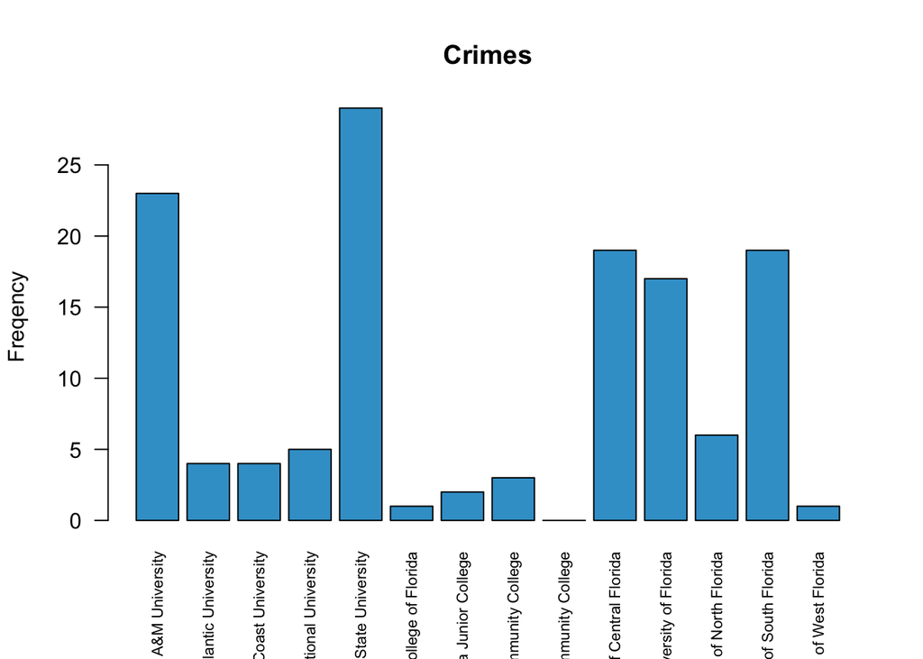

```r
# plot(df$enrollment,df$Crimes, xlab = "Enrollment", ylab = "Crimes")
barplot(df$Crimes,
        names.arg = df$University.College,
        main="Crimes",
        ylab="Freqency",
        las=2,
        cex.names = 0.7,
        col= c("#3CA0D0")
        )
```

**Example**

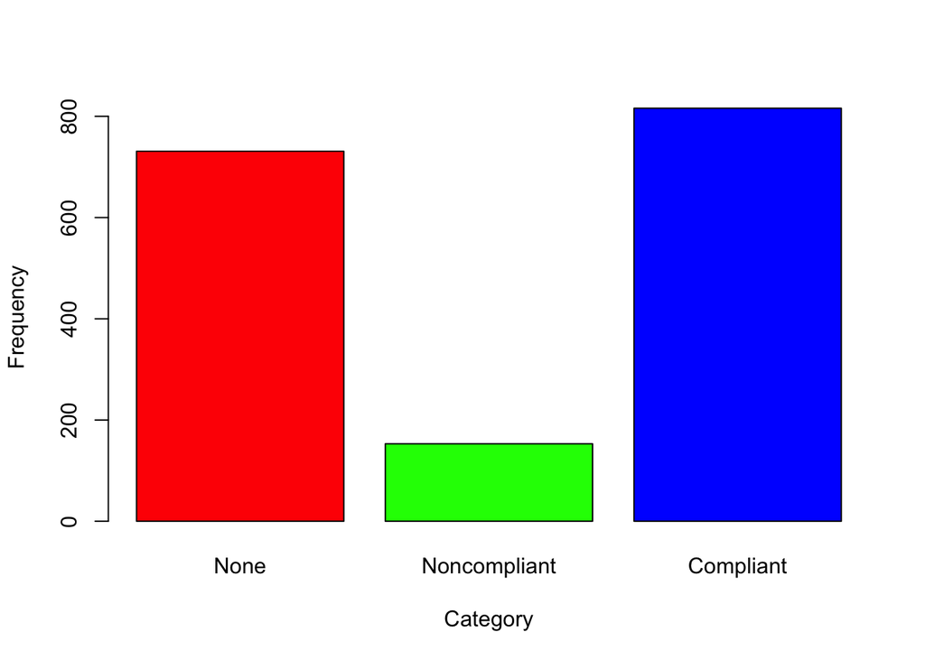

```r
helmets = data.frame(Category = c("None", "Noncompliant", "Compliant"), Frequency = c(731,153,816))

barplot(helmets$Frequency, names.arg = helmets$Category, col = rainbow(3),
        xlab = "Category",
        ylab = "Frequency")
```

**Example** (Graduation Rates): Graduation rates for 61 NCAA Men’s Division 1 basketball teams that made it to the tournament along with graduation rates of all athletes from the associated school were reported.

```r
grad_rates = read.csv("../data/examples/ex_110.csv")
head(grad_rates)
```

```
##    BB ALL DIFF
## 1  63  75   12
## 2  56  57    1
## 3  31  86   55
## 4  20  64   44
## 5  38  69   31
## 6 100  85  -15
```

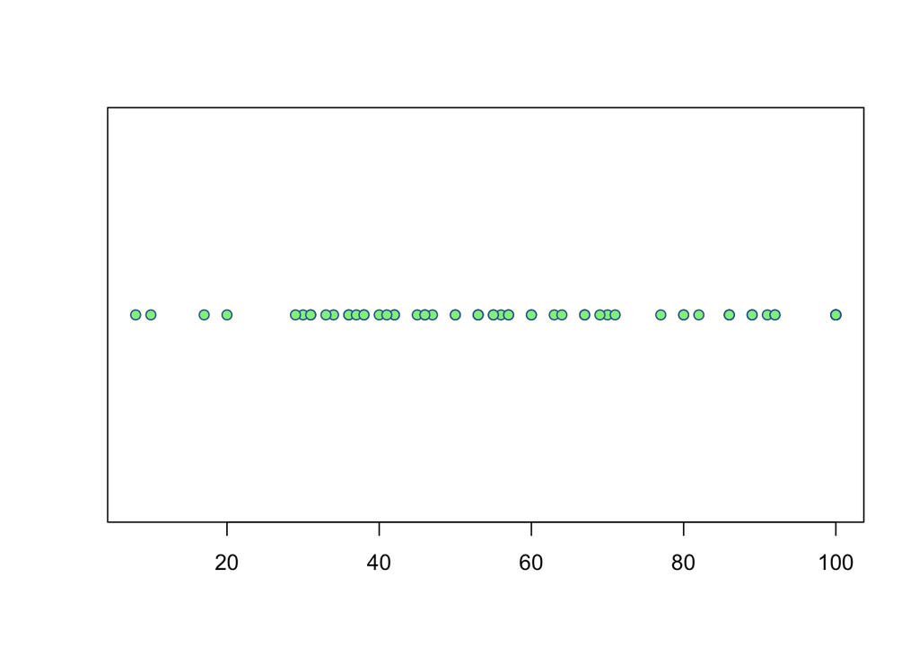

```r
stripchart(grad_rates$BB,  pch = 21, col = "#336699", bg="lightgreen")
```

## Exercises

1.1 Give a brief definition of the terms *descriptive statistics* and *inferential statistics*.

**Answer**: See page 7.

1.5. A university of 15000 students is interested in the proportion of students favor changing grade scheme. Two hundred students are sampled. What is the population of interest and what is the group of students that constitue the sample?

**Answer**: Population is all 15000 students and the sample consists of 200 of them.

#### References

Peck, R., & Devore, J. L. (2011). *Statistics: The exploration & analysis of data*. Cengage Learning.